# Supervised Learning with EIA Data

The following is a simple machine learning project that leverages on the [‘caret’](http://topepo.github.io/caret/index.html) package in R and fundamental supply and demand data from the U.S. EIA to explore numerical relationships in energy markets.

The objective will be to explore if fundamental variables such as U.S. Oil Production and Consumption have a meaningful predictive relationship with the prices of U.S. Crude Oil benchmarks such as West Texas Intermediate Crude.

### 1. Import Libraries

```r
# Import all required libraries
library(broom)
library(caret)
library(knitr)
library(PerformanceAnalytics)
library(Quandl)
library(sigr)
library(tidyverse)
```

```r
# Import data from the EIA Database in Quandl
wti <- Quandl(code = "CHRIS/ICE_T1", type = "xts")  # West Texas Intermediate Traded Prices
inv <- Quandl(code = "EIA/STEO_COSXPUS_M", type = "xts")  # U.S. Crude Oil Inventories
prod <- Quandl(code = "EIA/STEO_COPRPUS_M", type = "xts")  # U.S. Crude Oil Production
impts <- Quandl(code = "EIA/PET_MCEIMUS1_M", type = "xts")  # U.S. Crude Oil Imports
refy <- Quandl(code = "EIA/PET_MOPUEUS2_M", type = "xts")  # U.S. Refinery Percent Utilization Rates
cons <- Quandl(code = "EIA/STEO_TETCFUEL_M", type = "xts")  # U.S. Total Energy Consumption
gdp <- Quandl(code = "EIA/STEO_GDPQXUS_PCT_M", type = "xts")  # U.S. Real GDP

# Examine the structure of the 'wti' xts object
str(wti)
```

```
An ‘xts’ object on 2006-02-03/2019-06-14 containing:
  Data: num [1:3403, 1:11] 64.8 66.3 64.8 63 62.7 ...
 - attr(*, "dimnames")=List of 2
  ..$ : NULL
  ..$ : chr [1:11] "Open" "High" "Low" "Settle" ...
  Indexed by objects of class: [Date] TZ: UTC
  xts Attributes:
 NULL
```

```r
head(wti)
```

```
            Open  High   Low Settle Change Wave Volume Prev. Day Open Interest EFP Volume EFS Volume
2006-02-03 64.77 65.48 63.93  65.37     NA   NA  21966                   11070          0          0
2006-02-06 66.35 66.50 64.77  65.11  -0.26   NA  20387                   10998          0          0
2006-02-07 64.82 64.90 62.81  63.09  -2.02   NA  29434                   13611          0          0
2006-02-08 62.96 63.44 62.29  62.55  -0.54   NA  27539                   13583          0          0
2006-02-09 62.68 63.73 62.38  62.62   0.07   NA  27492                   21976          0          0
2006-02-10 62.87 63.00 61.35  61.84  -0.78   NA  21129                   21733          0          0
           Block Volume
2006-02-03            0
2006-02-06            0
2006-02-07            0
2006-02-08            0
2006-02-09            0
2006-02-10            0
```

```r
tail(wti)
```

```
            Open  High   Low Settle Change  Wave Volume Prev. Day Open Interest EFP Volume EFS Volume
2019-06-07 53.25 54.32 52.63  53.99   1.40 53.46  51372                   63582         NA         NA
2019-06-10 54.24 54.91 53.05  53.26  -0.73 53.89  45528                   59551         NA         NA
2019-06-11 53.36 54.03 52.95  53.27   0.01 53.54  42986                   59335         NA         NA
2019-06-12 52.82 52.82 50.74  51.14  -2.13 51.87  48256                   59336         NA         NA
2019-06-13 51.21 53.45 50.94  52.28   1.14 52.55  54775                   57979         NA         NA
2019-06-14 52.10 52.97 51.70  52.51   0.23 52.45  35247                   47508         NA         NA
           Block Volume
2019-06-07         1077
2019-06-10           16
2019-06-11          988
2019-06-12          419
2019-06-13        10500
2019-06-14         6222
```

Quandl Data on WTI Traded Futures roughly extends from Feb 2006 to Jun 2019.

### 2. Basic Exploratory Data Analysis

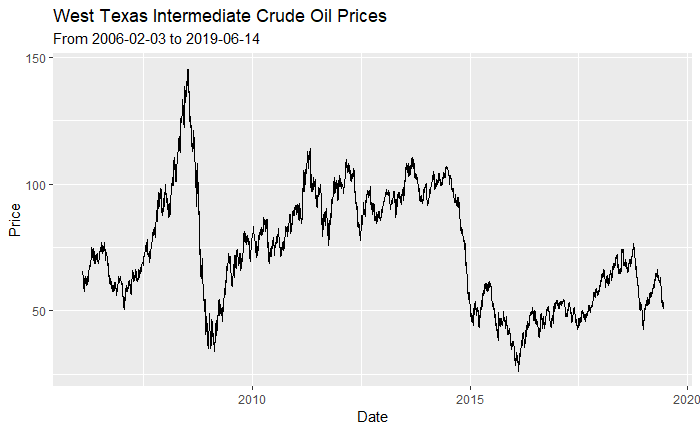

```r
# Plot a time series chart of West Texas Intermediate Closing Prices from 2006 to 2019
ggplot(data = wti, mapping = aes(x= index(wti), y = Settle)) +
  geom_line() +
  labs(title = "West Texas Intermediate Crude Oil Prices", subtitle = "From 2006-02-03 to 2019-06-14") +
  xlab("Date") +
  ylab("Price")
```

The price series of WTI Crude Oil broadly reflects trends in energy markets: a large rally and decline post-GFC, mean-reverting markets between 2010 and 2015, the infamous collapse to ~$30/bbl in Q1 2016 and associaated volatility between 2018 and 2019.

```r
# Examine the structure of the 'prod' xts object
str(prod)
```

```
An ‘xts’ object on Jan 1990/Dec 2020 containing:
  Data: num [1:372, 1] 7.55 7.5 7.43 7.41 7.33 ...
  Indexed by objects of class: [yearmon] TZ: UTC
  xts Attributes:
 NULL
```

```r
head(prod)
```

```
             [,1]
Jan 1990 7.546173
Feb 1990 7.497242
Mar 1990 7.433341
Apr 1990 7.407173
May 1990 7.328342
Jun 1990 7.105838
```

```r
tail(prod)
```

```
             [,1]
Jul 2020 13.21887
Aug 2020 13.32012
Sep 2020 13.41177
Oct 2020 13.31354
Nov 2020 13.51125
Dec 2020 13.50069
```

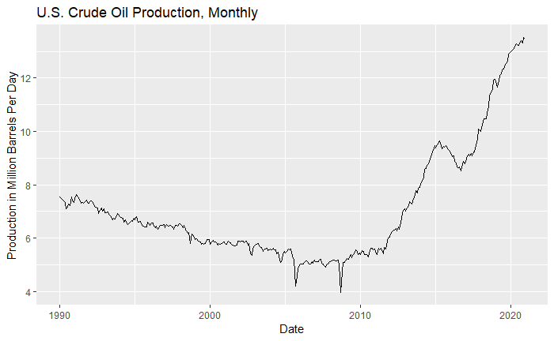

```r
names(prod) <- "Production"

ggplot(data = prod, mapping = aes(x = index(prod), y = Production)) +
  geom_line() +
  labs(title = "U.S. Crude Oil Production, Monthly") +
  xlab("Date") +
  ylab("Production in Million Barrels Per Day")
```

A quick analaysis of the time series plot of U.S. Crude Oil Production highlights a number of interesting features: amongst them, the sharp increase in monthly production numbers after 2010 - a likely effect of the U.S. Shale Revolution, a dramatic increase in “tight oil” supplies owing to fracking and horizontal drilling.

```r
# Examine the structure of the 'refy' xts object
str(refy)
```

```
An ‘xts’ object on Jan 1985/Mar 2019 containing:
  Data: num [1:411, 1] 74 73.8 73.7 76.5 78.4 79.3 80.8 77.7 76.9 78.6 ...
  Indexed by objects of class: [yearmon] TZ: UTC
  xts Attributes:
 NULL
```

```r
head(refy)
```

```
         [,1]
Jan 1985 74.0
Feb 1985 73.8
Mar 1985 73.7
Apr 1985 76.5
May 1985 78.4
Jun 1985 79.3
```

```r
tail(refy)
```

```
         [,1]
Oct 2018 90.0
Nov 2018 94.1
Dec 2018 95.4
Jan 2019 91.1
Feb 2019 85.8
Mar 2019 86.1
```

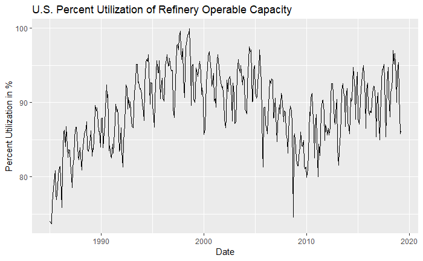

```r
names(refy) <- "Utilization"

ggplot(data = refy, mapping = aes(x = index(refy), y = Utilization)) +
  geom_line() +
  labs(title = "U.S. Percent Utilization of Refinery Operable Capacity") +
  xlab("Date") +
  ylab("Percent Utilization in %")
```

One of the more interesting patterns in the energy market is the presence of seasonality in refinery utilization rates: utilization rates sharply increase in the summer driving months owing to increased motor gasoline demand. Conversely, run rates tend to decrease in the fall owing to turnarounds and weaker product demand.

### 3. Data Preprocessing

```r
# Convert the daily WTI time series to a monthly time series on 'Settle'
wti_monthly <- to.monthly(wti$Settle)

# Examine the monthly WTI xts object
str(wti_monthly)
```

```
An ‘xts’ object on Feb 2006/Jun 2019 containing:
  Data: num [1:161, 1:4] 65.4 62 66.7 73.7 70.3 ...
 - attr(*, "dimnames")=List of 2
  ..$ : NULL
  ..$ : chr [1:4] "wti$Settle.Open" "wti$Settle.High" "wti$Settle.Low" "wti$Settle.Close"
  Indexed by objects of class: [yearmon] TZ: UTC
  xts Attributes:
 NULL
```

```r
head(wti_monthly)
```

```
         wti$Settle.Open wti$Settle.High wti$Settle.Low wti$Settle.Close
Feb 2006           65.37           65.37          57.65            61.41
Mar 2006           61.97           67.15          59.96            66.63
Apr 2006           66.74           75.17          66.23            71.88
May 2006           73.70           74.61          68.53            71.29
Jun 2006           70.34           73.93          68.56            73.93
Jul 2006           74.04           77.03          72.66            74.40
```

```r
tail(wti_monthly)
```

```
         wti$Settle.Open wti$Settle.High wti$Settle.Low wti$Settle.Close
Jan 2019           46.54           54.23          46.54            53.79
Feb 2019           55.26           57.26          52.41            57.22
Mar 2019           55.80           60.23          55.80            60.14
Apr 2019           61.59           66.30          61.59            63.91
May 2019           63.60           63.60          53.50            53.50
Jun 2019           53.25           53.99          51.14            52.51
```

```r
# Combine all time series into a single object for analysis
oil <- merge(wti_monthly, inv, prod, impts, refy, cons, gdp)

# Drop the Open, High, Low columns from oil
oil <- oil[, -c(1, 2, 3)]

# Filter to a subset with available data on all variables
oil <- oil["2006-02/2019-03"]

# Rename columns
names(oil) <- c("price", "inv", "prod", "impts", "util", "cons", "gdp")

# Conver the xts object to a data.frame
oil <- as.data.frame(oil)

# Examine the oil data.frame object
str(oil)
```

```
'data.frame':   158 obs. of  7 variables:
 $ price: num  61.4 66.6 71.9 71.3 73.9 ...
 $ inv  : num  326 326 331 324 321 ...
 $ prod : num  5.03 5.03 5.08 5.15 5.16 ...
 $ impts: num  279152 301243 294777 318687 321369 ...
 $ util : num  86.5 85.8 88 91.2 93 92.5 93.2 93 87.9 88 ...
 $ cons : num  8.21 8.61 7.73 7.98 8.16 ...
 $ gdp  : num  3.37 3.34 3.28 3.14 2.94 ...
```

```r
head(oil)
```

|  | price | inv | prod | impts | util | cons | gdp |
| --- | --- | --- | --- | --- | --- | --- | --- |
| Feb 2006 | 61.41 | 326.383 | 5.031930 | 279152 | 86.5 | 8.209513 | 3.370957 |
| Mar 2006 | 66.63 | 326.417 | 5.027168 | 301243 | 85.8 | 8.605115 | 3.343685 |
| Apr 2006 | 71.88 | 331.258 | 5.081652 | 294777 | 88.0 | 7.728664 | 3.275569 |
| May 2006 | 71.29 | 324.286 | 5.150561 | 318687 | 91.2 | 7.975749 | 3.138970 |
| Jun 2006 | 73.93 | 320.523 | 5.162796 | 321369 | 93.0 | 8.164176 | 2.944629 |
| Jul 2006 | 74.40 | 315.387 | 5.094173 | 317114 | 92.5 | 8.651295 | 2.471555 |

```r
tail(oil)
```

|  | price | inv | prod | impts | util | cons | gdp |
| --- | --- | --- | --- | --- | --- | --- | --- |
| Oct 2018 | 65.31 | 432.459 | 11.55895 | 226679 | 90.0 | 8.094910 | 2.941433 |
| Nov 2018 | 50.93 | 448.607 | 11.92607 | 224694 | 94.1 | 8.476201 | 2.961309 |
| Dec 2018 | 45.41 | 441.794 | 11.96301 | 220059 | 95.4 | 9.042961 | 3.011283 |
| Jan 2019 | 53.79 | 448.804 | 11.86025 | 233126 | 91.1 | 9.509997 | 3.166493 |
| Feb 2019 | 57.22 | 451.728 | 11.66446 | 186243 | 85.8 | 8.358039 | 3.219673 |
| Mar 2019 | 60.14 | 459.322 | 11.90481 | 209541 | 86.1 | 8.713408 | 3.246309 |

### 4. Univariate Linear Regression

```r
# Explore Linear Regression with one variable: Production
fmla_lm <- as.formula("price ~ prod")

# Train a Linear Regression model
model_lm <- lm(formula = fmla_lm, data = oil)

# Examine the results of the model fit
summary(model_lm)
```

```
Call:
lm(formula = fmla_lm, data = oil)

Residuals:
    Min      1Q  Median      3Q     Max
-42.542 -16.714  -2.648  16.056  55.778

Coefficients:
            Estimate Std. Error t value Pr(>|t|)
(Intercept) 107.4593     5.7481  18.695  < 2e-16 ***
prod         -4.5229     0.7615  -5.939  1.8e-08 ***
---
Signif. codes:  0 ‘***’ 0.001 ‘**’ 0.01 ‘*’ 0.05 ‘.’ 0.1 ‘ ’ 1

Residual standard error: 20.1 on 156 degrees of freedom
Multiple R-squared:  0.1844,    Adjusted R-squared:  0.1792
F-statistic: 35.28 on 1 and 156 DF,  p-value: 1.798e-08
```

```r
glance(model_lm)
```

| r.squared | adj.r.squared | sigma | statistic | p.value | df | logLik | AIC | BIC | deviance | df.residual |
| --- | --- | --- | --- | --- | --- | --- | --- | --- | --- | --- |
| 0.1844213 | 0.1791933 | 20.0987 | 35.27523 | 1.797631e-08 | 2 | -697.2894 | 1400.579 | 1409.767 | 63017.41 | 156 |

```r
wrapFTest(model_lm)
```

```
[1] "F Test summary: (R2=0.1844, F(1,156)=35.28, p<1e-05)."
```

A quick regression exercise with the lm() function shows that predicting WTI prices with just U.S. Production numbers leads to a mere R-Squared Value of ~0.18. (Roughly 18% of the variance in WTI prices is explained by the linear model)

The coefficient on the ‘prod’ variable is, however, highly significant with a p-value of 1.8e-08. This suggests that there may be some predictive value in analyzing U.S. Crude Oil Production numbers.

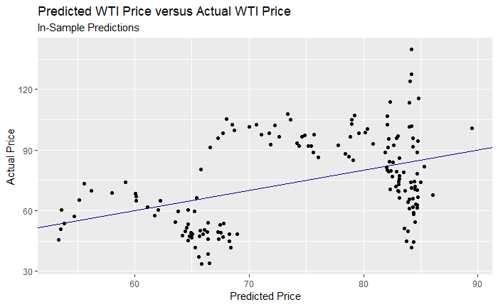

```r
# Visualize a linear model between price and prod
oil$pred <- predict(model_lm)

# Plot the Actual Prices against the Model's Predicted Prices
ggplot(data = oil, mapping = aes(x = pred, y = price)) +
  geom_point() +
  geom_abline(color = "darkblue") +
  labs(title = "Predicted WTI Price versus Actual WTI Price", subtitle = "In-Sample Predictions") +
  xlab("Predicted Price") +
  ylab("Actual Price")
```

```r
# Remove the predictions from the univariate linear model
oil <- oil %>% select(-pred)
```

Plotting the Actual Prices against Model Predicted Price shows a roughly-poor fit. In the next step, we attempt to add more potentially-meaningful variables to the linear model and re-assess the predictive performance.

### 5. Train-Test Split

```r
# Set seed to 42 to replicate randomized results
set.seed(42)

# Shuffle the rows of the data.frame
permuted_rows <- sample(nrow(oil))
shuffled_oil <- oil[permuted_rows, ]

# Implement a split at 80%/20% of data
split <- round(nrow(shuffled_oil) * 0.80)

# Training Data defined as rows prior to 80%
oil_train <- shuffled_oil[1:split, ]

# Testing Data defined as rows after 80%
oil_test <- shuffled_oil[(split + 1):nrow(shuffled_oil), ]

# Examine both the training and testing datasets
str(oil_train)
```

```
'data.frame':   126 obs. of  7 variables:
 $ price: num  79.7 95.4 65.3 103 64.9 ...
 $ inv  : num  322 334 432 348 423 ...
 $ prod : num  5.55 5.58 11.56 6.3 10.46 ...
 $ impts: num  245302 277050 226679 271888 236086 ...
 $ util : num  81.1 89 90 85.6 91.3 88.9 86.1 90.4 81.3 85.8 ...
 $ cons : num  8.21 7.89 8.09 7.67 8.68 ...
 $ gdp  : num  1.73 1.55 2.94 2.75 2.65 ...
```

```r
str(oil_test)
```

```
'data.frame':   32 obs. of  7 variables:
 $ price: num  59.5 105.4 96 127.3 58.1 ...
 $ inv  : num  439 354 268 286 307 ...
 $ prod : num  9.34 8.72 5.11 5.14 5.11 ...
 $ impts: num  219618 212025 304870 296685 316538 ...
 $ util : num  93.7 90.3 88.7 88.8 88.2 88.4 84.4 90.2 82.7 91.1 ...
 $ cons : num  7.9 7.78 9.12 7.9 9.25 ...
 $ gdp  : num  3.12 2.85 1.78 1.13 1.63 ...
```

### 6. Standardisation of Training Folds

```r
# Create a 5-fold object
myFolds <- createFolds(oil_train$price, k = 5)

# Define a standardized trainControl object for caret::train()
myControl <- trainControl(savePredictions = TRUE, index = myFolds)
```

### 7. Training with a glmnet model

The first model that we will attempt to train the data on is a “glmnet” model. Roughly speaking, this stands for “Generalized Linear Model” with penalties for the number of non-zero coefficients and/or the absolute magnitude of coefficients.

We will train the model on all 6 predictor variables whilst iterating with a Grid Search object that optimizes for the alpha and lambda parameters of the model.

```r
# Create a Grid Search object for the glmnet Linear Regression model
myGrid <- expand.grid(alpha = 0:1, lambda = seq(0.0001, 0.1, length = 10))

# Train a glmnet model on the training dataset
model_glmnet <- train(
  price ~ .,
  data = oil_train,
  method = "glmnet",
  tuneGrid = myGrid,
  trControl = myControl,
  preProcess = c("medianImpute", "center", "scale", "pca")
)

# Return a summary of the glmnet_model
print(model_glmnet)
```

```
glmnet

126 samples
  6 predictor

Pre-processing: median imputation (6), centered (6), scaled (6), principal component signal extraction (6)
Resampling: Bootstrapped (5 reps)
Summary of sample sizes: 25, 24, 26, 25, 26
Resampling results across tuning parameters:

  alpha  lambda  RMSE      Rsquared   MAE
  0      0.0001  16.74920  0.4663077  13.25434
  0      0.0112  16.74920  0.4663077  13.25434
  0      0.0223  16.74920  0.4663077  13.25434
  0      0.0334  16.74920  0.4663077  13.25434
  0      0.0445  16.74920  0.4663077  13.25434
  0      0.0556  16.74920  0.4663077  13.25434
  0      0.0667  16.74920  0.4663077  13.25434
  0      0.0778  16.74920  0.4663077  13.25434
  0      0.0889  16.74920  0.4663077  13.25434
  0      0.1000  16.74920  0.4663077  13.25434
  1      0.0001  16.92780  0.4669820  13.35395
  1      0.0112  16.92780  0.4669820  13.35395
  1      0.0223  16.92780  0.4669820  13.35395
  1      0.0334  16.92780  0.4669820  13.35395
  1      0.0445  16.92784  0.4669825  13.35401
  1      0.0556  16.92633  0.4670826  13.35305
  1      0.0667  16.92322  0.4672443  13.35098
  1      0.0778  16.91848  0.4673992  13.34781
  1      0.0889  16.91361  0.4675530  13.34455
  1      0.1000  16.90877  0.4677063  13.34128

RMSE was used to select the optimal model using the smallest value.
The final values used for the model were alpha = 0 and lambda = 0.1.
```

```r
summary(model_glmnet)
```

```
            Length Class      Mode
a0          100    -none-     numeric
beta        500    dgCMatrix  S4
df          100    -none-     numeric
dim           2    -none-     numeric
lambda      100    -none-     numeric
dev.ratio   100    -none-     numeric
nulldev       1    -none-     numeric
npasses       1    -none-     numeric
jerr          1    -none-     numeric
offset        1    -none-     logical
call          5    -none-     call
nobs          1    -none-     numeric
lambdaOpt     1    -none-     numeric
xNames        5    -none-     character
problemType   1    -none-     character
tuneValue     2    data.frame list
obsLevels     1    -none-     logical
param         0    -none-     list
```

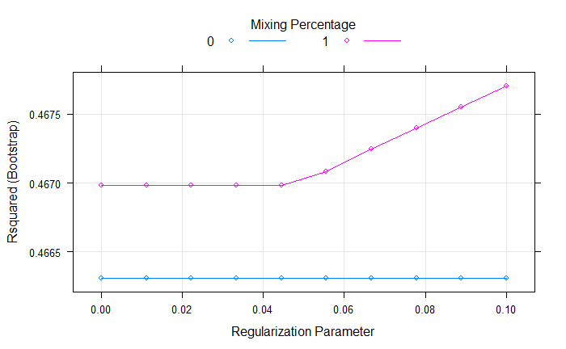

```r
# Visualize the results of the glmnet model
plot(model_glmnet, metric = "Rsquared")
```

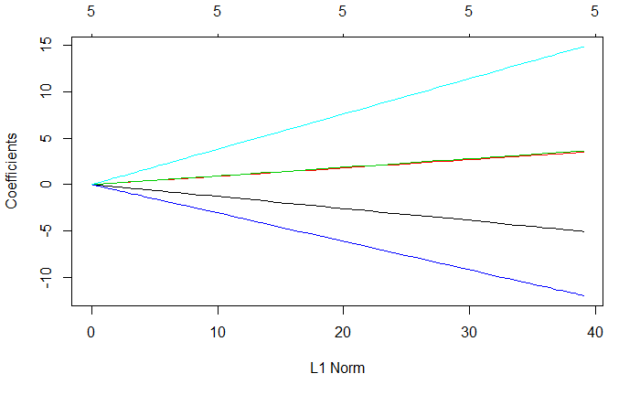

```r
plot(model_glmnet$finalModel)
```

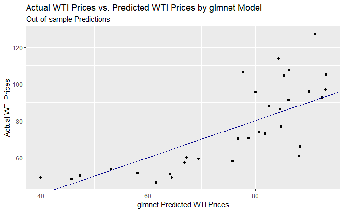

```r
# Generate predictions for the testing dataset with predict()
oil_test$pred_glmnet <- predict(model_glmnet, oil_test)

# Visualize the results of the predictive modelling
ggplot(data = oil_test, mapping = aes(x = pred_glmnet, y = price)) +
  geom_point() +
  geom_abline(color = "darkblue") +
  labs(title = "Actual WTI Prices vs. Predicted WTI Prices by glmnet Model", subtitle = "Out-of-sample Predictions") +
  xlab("glmnet Predicted WTI Prices") +
  ylab("Actual WTI Prices")
```

Analysis of the plot of Actual Prices against Predicted Prices shows a much better fit relative to the first-stage univariate regression model. The glmnet model returns an R-Squared value of ~0.47, which is better than the first model but stands to be improved.

In the next stage, we will attempt to train a Random Forest model on the training data to see if predictive performance improves.

### 8. Training with a Random Forest Model

```r
# Train a Random Forest model on the oil_train dataset
model_rf <- train(
  price ~ .,
  data = oil_train,
  method = "ranger",
  trControl = myControl,
)

# Return a summary of the model_rf object
print(model_rf)
```

```
Random Forest

126 samples
  6 predictor

No pre-processing
Resampling: Bootstrapped (5 reps)
Summary of sample sizes: 25, 24, 26, 25, 26
Resampling results across tuning parameters:

  mtry  splitrule   RMSE      Rsquared   MAE
  2     variance    16.52933  0.4929283  13.03743
  2     extratrees  16.22809  0.5351375  12.99426
  4     variance    16.17652  0.5200329  12.60434
  4     extratrees  15.44374  0.5754885  11.98201
  6     variance    16.21201  0.5249427  12.58239
  6     extratrees  15.15456  0.5914232  11.59130

Tuning parameter 'min.node.size' was held constant at a value of 5
RMSE was used to select the optimal model using the smallest value.
The final values used for the model were mtry = 6, splitrule = extratrees and min.node.size = 5.
```

```r
summary(model_rf)
```

```
                          Length Class         Mode
predictions               126    -none-        numeric
num.trees                   1    -none-        numeric
num.independent.variables   1    -none-        numeric
mtry                        1    -none-        numeric
min.node.size               1    -none-        numeric
prediction.error            1    -none-        numeric
forest                      8    ranger.forest list
splitrule                   1    -none-        character
treetype                    1    -none-        character
r.squared                   1    -none-        numeric
call                        9    -none-        call
importance.mode             1    -none-        character
num.samples                 1    -none-        numeric
replace                     1    -none-        logical
xNames                      6    -none-        character
problemType                 1    -none-        character
tuneValue                   3    data.frame    list
obsLevels                   1    -none-        logical
param                       0    -none-        list
```

We see that the Random Forest model performs slightly better than the glmnet model, with Rsquared up to ~0.60 with mtry = 6.

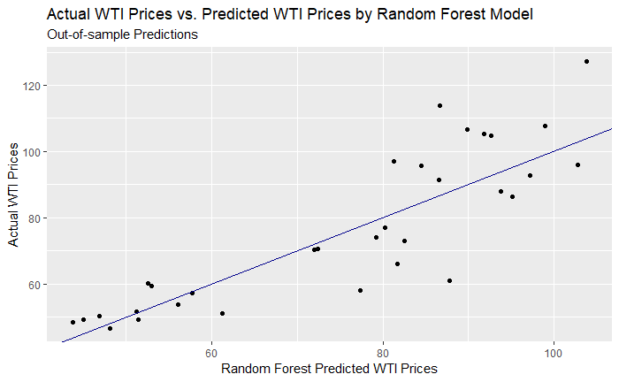

```r
# Generate predictions for the testing dataset with predict()
oil_test$pred_rf <- predict(model_rf, oil_test)

# Visualize the results of the predictive modelling
ggplot(data = oil_test, mapping = aes(x = pred_rf, y = price)) +
  geom_point() +
  geom_abline(color = "darkblue") +
  labs(title = "Actual WTI Prices vs. Predicted WTI Prices by Random Forest Model", subtitle = "Out-of-sample Predictions") +
  xlab("Random Forest Predicted WTI Prices") +
  ylab("Actual WTI Prices")
```

### 9. Evaluating the Performance of Multiple Models

```r
# Create a list of trained models: model_list
model_list <- list(glmnet = model_glmnet, rf = model_rf)

# Use caret::resampels() to generate evaluative statistics for each model
resamps <- resamples(model_list)

# Print the resamples object
print(resamps)
```

```
Call:
resamples.default(x = model_list)

Models: glmnet, rf
Number of resamples: 5
Performance metrics: MAE, RMSE, Rsquared
Time estimates for: everything, final model fit
```

```r
# Print a summary of the resamples object
summary(resamps)
```

```
Call:
summary.resamples(object = resamps)

Models: glmnet, rf
Number of resamples: 5

MAE
           Min.  1st Qu.   Median     Mean  3rd Qu.     Max. NA's
glmnet 11.58305 12.86944 13.27333 13.25434 13.79102 14.75486    0
rf      9.82671 11.47336 12.02883 11.59130 12.21542 12.41220    0

RMSE
           Min.  1st Qu.   Median     Mean  3rd Qu.     Max. NA's
glmnet 14.68195 16.45128 16.53558 16.74920 17.07722 18.99997    0
rf     12.60119 15.21433 15.54665 15.15456 15.66126 16.74937    0

Rsquared
            Min.   1st Qu.    Median      Mean   3rd Qu.      Max. NA's
glmnet 0.4107755 0.4541839 0.4658841 0.4663077 0.4868779 0.5138170    0
rf     0.4800754 0.5455232 0.5960601 0.5914232 0.6620406 0.6734166    0
```

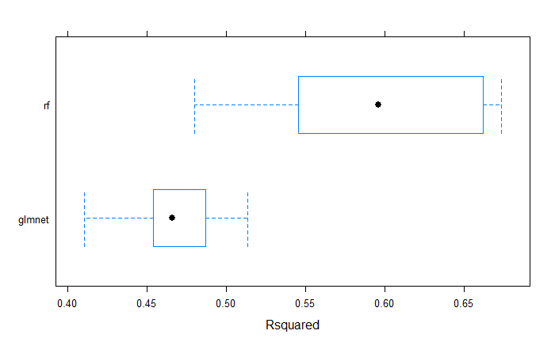

```r
bwplot(resamps, metric = "Rsquared")
```

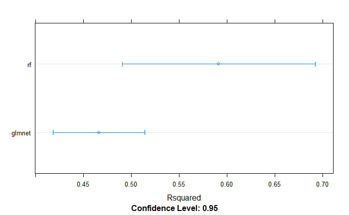

```r
dotplot(resamps, metric = "Rsquared")
```

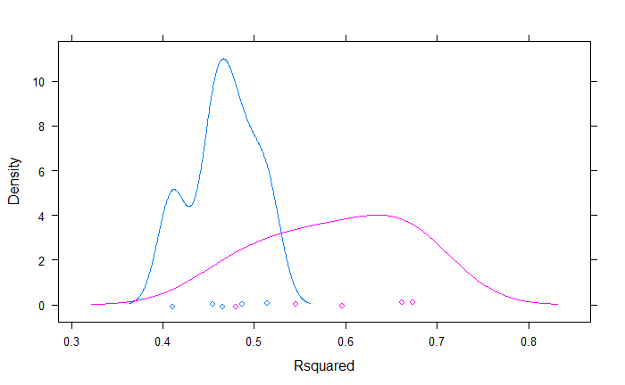

```r
densityplot(resamps, metric = "Rsquared")
```

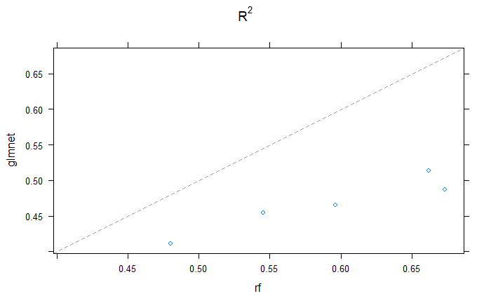

```r
xyplot(resamps, metric = "Rsquared")
```

### 10. Final Conclusions

Using R-Squared as an evaluation parameter, the Random Forest model appears to perform quite well with a median R-Squared value of 0.60, compared to the Linear Regression model with 0.47. This roughly suggests that the Random Forest ensemble method is able to explain 60% of the variance in WTI Contract Prices given features that encompass fundamental factors such as Production, Consumption and GDP.

Further research into the literature on energy markets may be possible with respect to factors that are salient fro the prediction of Crude Oil Prices. Future implementations could include expanding the feature space to more than 6 variables to derive better prediction performance.

```r
purl("supervised-learning-with-eia-data.Rmd")
```

```
processing file: supervised-learning-with-eia-data.Rmd
```

[output not shown]

```
output file: supervised-learning-with-eia-data.R
```

```
[1] "supervised-learning-with-eia-data.R"
```